# Final Foodweb Analyses

# Analysis of the California Rocky Intertidal Zone Food Web

```r
#install.packages("igraph")
#install.packages("network")
#install.packages("sna")
#install.packages("ggraph")
#install.packages("visNetwork")
#install.packages("threejs")
#install.packages("networkD3")
#install.packages("ndtv")
#install.packages("tidyverse")
#install.packages("NetIndices")
#install.packages("cheddar")
#install.packages("grDevices")

library(igraph)
library(network)
library(sna)
library(ggraph)
library(visNetwork)
library(threejs)
library(networkD3)
library(ndtv)
library(tidyverse)
library(viridis)
library(cheddar)
library(kableExtra)
library(needs)

prioritize(dplyr)
```

## Part One: Summary Statistics and Graphs

### Reading in the cleaned versions of the data from October 2024

(we created and saved these csvs in the final_foodweb_build RMD)

```r
nodes_orig <- read_csv("data/foodweb_V8/nodes_final_8oct2024.csv") %>%
  mutate(parasite = case_when(str_detect(trophic_strategy, "parasit") ~ "y",
                              trophic_strategy == "pathogen" ~ "y",
                              .default = "n")) %>%
  unite(node, c(nodeNum, species), sep = "_", remove = FALSE) %>%  # downstream, cheddar requires a column called node that is non-numeric to identify each unique node
  # adding helpful life stage info to node name
  mutate(nodeID = case_when(life_stage == "adult" ~paste(node), # dont change
                          life_stage == "hydroid colony" ~paste(node), # dont change
                          life_stage == "multiple" ~paste(node), # dont change
                          TRUE ~ paste(node, life_stage, sep = "_"))) %>%

  # i changed the names of some cols for clarity, so doing that here (make sure consistent downstream)
  rename(nodeTaxon = species,
         category = organismal_category,
         life_stage_code = clean_stage,
         grouping_habits = solitary_aggregating_colonial,
         reference = reference_justification,
         mobility = mobile_or_sessile
         ) %>%
  # select and reorder
  dplyr::select(node, nodeID, nodeNum, nodeTaxon, synonymies, category, common_name, life_stage, life_stage_code, province, commonality, reference, zone, habitat_notes, grouping_habits, mobility, trophic_strategy, node_type, node_resolution, aphia, kingdom, phylum, class, order, family, genus, parasite)
#view(nodes)

all_links <- read_csv("data/foodweb_V8/links_final_8oct2024.csv")
# calling the links list "links" but it's ONLY trophic links
#also switched from using the uncollapsed link list (~15k links) to the [final] list with no duplicates (~14k links)

links_orig <- all_links %>% # i dont think we need to make downstream changes to this df

  # need to remove non-trophic interactions!
  filter(interaction.type != 2, #epibiont
         interaction.type !=9, #endocommensal
         interaction.type !=10, #ectocommensal
         interaction.type !=22, #mutualism
         #interaction.type !=28, #boring # i think we need to leave boring in because of the gammarids that bore and eat
         interaction.type != 29) %>%

  # and finally we need to add a column coding for parasitic interaction or nah
  mutate(parasitic = case_when(
    interaction.type > 4 & interaction.type < 8 ~ "y",
    interaction.type == 12 ~ "y",
    interaction.type > 23 & interaction.type < 27 ~ "y", # we're calling sessile micropredation parasitic here
    TRUE ~ "n"
  )) %>%
  # rename some columns to match what i put in column_descriptions.csv
  rename(interactionType = interaction.type,
         referenceNum = ref_num) %>%

  # make a new column that concatenates node name, num, and life stage bc cheddar can't handle numeric node names
  unite(resource, c(resourceNum, resourceName), sep = "_", remove = FALSE) %>%
  unite(consumer, c(consumerNum, consumerName), sep = "_", remove = FALSE) %>%
  rename(interactionZone = zone) %>%
  dplyr::select(resource, resourceNum, resourceName, resourceCat, resourceStage, consumer, consumerNum, consumerName, consumerCat, consumerStage, interactionType, referenceNum, justification, confidence, ref_location_code, localities, interactionZone, habitat, parasitic) # reorder so they match col descriptors
```

# INCORPORATING NATURE EDITS JULY/OCTOBER 2024

## Requested edits:

1. Revision of the trophic strategy column ==> consumer type (we will call it trophic category)??
2. Addition of a consumer strategy column categorizing all nodes using the 11 strategies defined by Lafferty et al., 2015
3. Deal with vague node IDs and historical human feeding links

### What I said we did

#### What Dana did trophic strategy wise:

Consumer.Strategy Organism feeding method. Values include: Autotroph, Castrator, Commensal, Detritivore, EctoCommensal, Ectoparasite, EggPredator, Endoparasite, Filter, Herbivore, MicroPredator, non-feeding, Omnivore, Pathogen, planktivore, Predator, Scavenger, Suspension

Consumer.Type Consumer strategy according to Lafferty and Kuris 2002. Values include: Castrator, Micropredator, non-feeding, Parasite, Pathogen, Predator, Trophically Transmitted Parasite

### Revision of the trophic strategy column into consumer strategy

herbivore/grazer, omnivore, carnivore (scavenger + predator), detritivore, symbiotic egg predator, mixotroph, primary producer (deposit feeder, filter feeder, mass feeder, parasitic, ??) more about HOW they acquire their food, not always mutually exclusive with consumer strategy, we do not include commensal but do include kleptoparasite to reflect organisms that eat their hosts food

```r
nodes1 <- nodes_orig %>%
  mutate(consumer_strategy = case_when(trophic_strategy == "typical predator" ~ "typical predator",
                                       trophic_strategy == "carnivore (scavenger + predator)" ~ "carnivore (scavenger + predator)",
                                       trophic_strategy == "omnivore" ~ "omnivore",
                                       trophic_strategy == "filter feeder" ~ "filter feeder",
                                       trophic_strategy == "scavenger" ~ "scavenger", # but this is supposed to be like social predator
                                       trophic_strategy == "grazer" ~ "grazer",
                                       trophic_strategy == "micropredator" ~ "micropredator",
                                       trophic_strategy == "symbiotic egg predator" ~ "symbiotic egg predator",
                                       trophic_strategy == "parasite" ~ "endoparasite",
                                       trophic_strategy == "ectoparasite" ~ "ectoparasite",
                                       trophic_strategy == "deposit feeder" ~ "deposit feeder",
                                       trophic_strategy == "primary producer" ~ "primary producer",
                                       # not sure if we have true decomposers...
                                       TRUE ~ as.character(trophic_strategy)
                                       ))
```

### Add a consumer strategy column to follow Lafferty et al 2015

If the resource is living and the consumer feeds on more than one prey/host: Predator – prey fitness is reduced to zero, deaths of prey are required to extend consumer life cycle, a single predator kills its prey (thus impact on a prey is density-independent), prey death does not lead to predator death. Examples: squids, mosquito larvae on algae. Social predator – like typical predators, but more predators per attacked prey kill prey more effectively. Examples: wolves on moose, army ants. Micropredator – prey/host fitness is not reduced to zero; death of the host is not required to continue consumer life cycle, impact on host is densitydependent. Examples: adult female mosquitos, cicadas, giraffes.

If the resource is living, death of the host leads to death of the consumer, and the consumer feeds on just a single individual resource (host): Macroparasite – Host fitness is not reduced to zero; impact on host is densitydependent (impact on the host increases with the number of parasites). Examples: adult schistosomes, malaria in mosquitos, corn borer grubs. Pathogen – Host fitness not necessarily reduced to zero, impact on host is densityindependent (impact is controlled by extent of effective host defenses, limiting the asexual reproduction of the consumer), Examples: malaria in humans, scale insects. Castrators – Host fitness reduced to zero; impact on host is density-independent. Examples: larval trematodes in snail hosts, Sacculina on crabs, boll weevil larvae. Parasitoid – Host fitness reduced to zero, consumer kills host to complete its life cycle; impact on host is intensity-independent. Examples: larval ichneumonid wasps, Pasteuria bacteria in Daphnia, bruchid beetles in seeds.

If the resource is not living (does not give birth), resources flux into the system: Detritivore – As for a predator, but feeds on non-living organic particles. Examples: earthworms, sand dollars. Scavenger – As for a social predator, but feeds dead organisms. Examples: marabou storks, hagfish, burying beetles Decomposer – As for a macroparasite, but feeds on a dead food source. Examples: termites, blow flies, oyster mushrooms. Autotroph –Resources (nutrients) either flow through the system or are recycled on the death of consumers, or both. Examples: plants, chemosynthetic bacteria. Plants are often also limited by space (which influences access to light), though space limitation does not define their consumer strategy.

```r
#unique(nodes_og$trophic_strategy)

nodes2 <- nodes1 %>%
  mutate(consumer_type = case_when(trophic_strategy == "typical predator" ~ "predator",
                                       trophic_strategy == "carnivore (scavenger + predator)" ~ "predator",
                                       trophic_strategy == "omnivore" ~ "predator",
                                       trophic_strategy == "filter feeder" ~ "predator",
                                       #nodeName == "Canis latrans" ~ "social predator", #idk if we have other social predators
                                       # on second thought, canis are normal predators in RIZ, just 1:1
                                       trophic_strategy == "scavenger" ~ "scavenger", # but this is supposed to be like social predator
                                       trophic_strategy == "grazer" ~ "micropredator",
                                       trophic_strategy == "micropredator" ~ "micropredator",
                                       trophic_strategy == "symbiotic egg predator" ~ "micropredator",
                                       trophic_strategy == "parasite" ~ "macroparasite",
                                       trophic_strategy == "ectoparasite" ~ "pathogen",
                                       trophic_strategy == "deposit feeder" ~ "detritivore",
                                       trophic_strategy == "primary producer" ~ "autotroph",
                                       # not sure if we have true decomposers...
                                       TRUE ~ as.character(trophic_strategy)
                                       )) %>%
  select(-trophic_strategy) # don't need this anymore
```

### removing parasite morphospecies that we couldn’t ID past Class level:

filter out node_resolution == Morphospecies and Class == NA

```r
#nodes3 <- nodes2 %>%
#  filter(!(node_resolution == "Morphospecies" & is.na(class)))

# decided to just do this manually in original nodes list
```

### Removing historical human feeding links:

Jaden made a dataframe called “prehistoric_human_diet.csv” - her opinion on what contemporary humans do NOT eat Some of these links were manually removed upstream for other reasons

```r
hist_human_diet <- read_csv("data/prehistoric_human_diet.csv")
removal_check <- semi_join(links_orig, hist_human_diet, by = join_by(resourceNum, consumerNum)) # anti join includes only nodes in the left that ARE not present in the right

links <- anti_join(links_orig, hist_human_diet, by = join_by(resourceNum, consumerNum)) # anti join includes only nodes in the left that are not present in the right
```

### Still some missing WORMS aphia IDs

```r
#input_names_id <- as_tibble(cbind(input_names, aphiaDF)) %>%
#  rename(nodeName = input_names,
#         aphia = aphiaDF)
#write_csv(input_names_id, "data/missing_aphias_15oct24.csv") # so i don't have to run this every fucking time
input_names_id <- read_csv("data/missing_aphias_15oct24.csv") %>%
  distinct(nodeName,aphia)
```

### Some minutiae:

## final time we will write csvs!! these are what we’re publishing

### need to go multiple places:

```r
nodes <- nodes2

# final time we will write csvs!! these are what we're publishing
# need to go multiple places:
write_csv(links, "data/foodweb_V8/trophic_links.csv")
write_csv(links, "/Users/zoe/Documents_Local/GitHub/zilz_etal_2024_FoodWebForCARIZ/links.csv")
#write_csv(links, "/Users/zoe/Library/CloudStorage/GoogleDrive-zilz@ucsb.edu/My Drive/SCHOOL/PHD_AT_UCSB/RIZ Food Web/Nature Data Paper Manuscript Materials/dataset/links.csv") # oct 10: NOT THIS ONE, we don't want to overwrite manual changes yet

write_csv(nodes, "data/foodweb_V8/trophic_nodes.csv") # this project
write_csv(nodes, "/Users/zoe/Documents_Local/GitHub/zilz_etal_2024_FoodWebForCARIZ/nodes.csv") # repo that we're publishing
#write_csv(nodes, "/Users/zoe/Library/CloudStorage/GoogleDrive-zilz@ucsb.edu/My Drive/SCHOOL/PHD_AT_UCSB/RIZ Food Web/Nature Data Paper Manuscript Materials/dataset/nodes.csv") # oct 10: NOT THIS ONE, we don't want to overwrite manual changes yet

# if you change these, don't forget to update the dryad AND push to git
```

## Switching to cheddar for the analyses

#### Our csvs have to be a little different now:

https://cran.r-project.org/web/packages/cheddar/vignettes/ImportExport.pdf ### OR we can manipulate our existing dataframes to fit cheddar’s standards (more reproducible but cheddar hates this and makes it hard)

```r
ca_riz_total
```

```
ca riz total containing 1844 nodes and 13216 trophic links
```

### some non-network metrics that food web papers usually report:

https://cran.r-project.org/web/packages/cheddar/vignettes/Community.pdf

```r
vals <- as.numeric(c(spnodes, fnodes, sp_fnodes, pnodes, sp_pnodes, plinks, basal, int, top, isolated))
```

[output not shown]

[figure not shown]

```r
# need to create function first
ToIgraph <- function(community, weight=NULL)
{
if(is.null(TLPS(community)))
{
stop('The community has no trophic links')
}
else
{
tlps <- TLPS(community, link.properties=weight)
if(!is.null(weight))
{
tlps$weight <- tlps[,weight]
}
return (graph_from_data_frame(tlps,
vertices=NPS(community),
directed=TRUE))
}
}

ca_riz_ig <- ToIgraph(ca_riz_total)
```

## Plot iGraph object and ready for publication

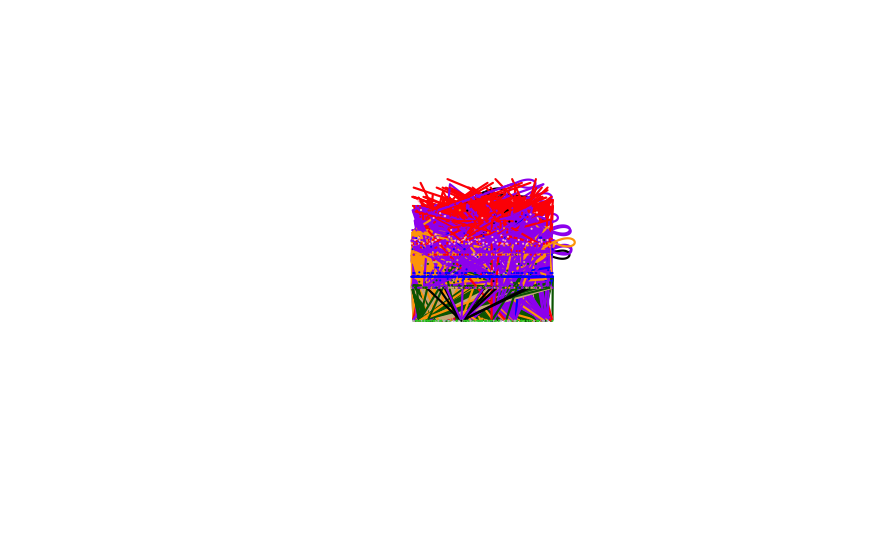

```r
############# set up igraph dataframes ################

# igraph requires that first two columns of link dataframe are "symbolic edge list"
igraph_links <- trophic.links %>%
  relocate(consumer, .after = resource) # need to make this from, to; so resource, consumer

igraph_nodes <- cheddar_nodes %>%
  mutate(trophic_level = trophic_levels) # need to add the trophic levels on here that we calculated using cheddar

############# make igraph object ################

trophic_web_psites1 <- graph_from_data_frame(d= igraph_links, # all links
                             vertices = igraph_nodes, # igraph filters out nodes that don't have any interactions automatically
                             directed=T) # this makes sure resources (from) "point" to consumers (to)

# save degree for later use and add it to nodes df:
deg <- igraph::degree(trophic_web_psites1, mode = "all")
igraph_nodes_1 <- igraph_nodes %>%
  mutate(degree = deg)

# remove unconnected nodes still remaining in web
isolated = which(igraph::degree(trophic_web_psites1)==0)
trophic_web_psites = delete_vertices(trophic_web_psites1, isolated)

# make the right length of trophic level vector, removing unconnected nodes from igraph_nodes and therefore their TLs
# very complicated, annoying
# first make the isolated igraph object into a dataframe and extract the node column
isolated.df <- as.data.frame(isolated) %>%
  rownames_to_column("node")
#then turn that column into a list
todelete <- as.list(isolated.df$node)
# then filter OUT any nodes that are in that list
igraph_nodes2 <- igraph_nodes_1 %>%
  filter(!node %in% todelete) #phew

# save degree for later use (probably not necessary to do again, but just in case)
deg <- igraph::degree(trophic_web_psites, mode = "all")

# make matrix for plotting
RIZadjmatrix <- as_adjacency_matrix(trophic_web_psites,
                                    sparse = FALSE)

############### create custom layout using trophic levels ################
# First we need to create a two-column matrix identifying the x and y values for each node.
layout.matrix.1 <- matrix(nrow=length(V(trophic_web_psites)), # Rows equal to the number of vertices
                        ncol=2)
layout.matrix.1[,1] <- runif(length(V(trophic_web_psites))) # randomly assign positions along x-axis (like jitter)
layout.matrix.1[,2] <- igraph_nodes2$trophic_level


############### pre set some colors for plotting #################
##### node colors: #####
V(trophic_web_psites)$color <- case_when(igraph_nodes2$consumer_strategy == "grazer" ~ "darkgreen",
                           igraph_nodes2$consumer_strategy == "micropredator" ~ "pink",
                           igraph_nodes2$consumer_strategy ==   "non-feeding" ~ "grey",
                           igraph_nodes2$consumer_strategy ==     "various (assemblage)" ~ "black",
                           igraph_nodes2$consumer_strategy ==     "detritivore" ~ "tan",
                           igraph_nodes2$consumer_strategy ==     "scavenger" ~ "tan",
                           igraph_nodes2$consumer_strategy ==     "deposit feeder" ~ "tan",
                           igraph_nodes2$consumer_strategy ==   "filter feeder" ~ "blue",
                           igraph_nodes2$consumer_strategy ==     "primary producer" ~ "limegreen",
                           igraph_nodes2$consumer_strategy ==     "mixotroph" ~ "limegreen",
                           igraph_nodes2$consumer_strategy ==     "omnivore" ~ "orange",
                           igraph_nodes2$consumer_strategy ==     "typical predator" ~ "purple",
                           igraph_nodes2$consumer_strategy ==     "carnivore (scavenger + predator)" ~ "purple",
                           igraph_nodes2$consumer_strategy ==     "parasite" ~ "red",
                           igraph_nodes2$consumer_strategy ==     "symbiotic egg predator" ~ "red",
                           igraph_nodes2$consumer_strategy ==     "endoparasite" ~ "red",
                           igraph_nodes2$consumer_strategy ==     "ectoparasite" ~ "red",
                           igraph_nodes2$consumer_strategy ==     "pathogen" ~ "red",
                           igraph_nodes2$consumer_strategy ==    "parasitic castrator" ~ "red",
                           .default = "black")

#V(trophic_web_psites)$color <- case_when(igraph_nodes2$parasite == "y" ~ "red",
#                                         igraph_nodes2$functional.group == "primary producer" ~ "green",
#                                         igraph_nodes2$functional.group == "mixotroph" ~ "green",
                                         #igraph_nodes2$functional.group == "detritivore" ~ "brown",
                                         #igraph_nodes2$functional.group == "deposit feeder" ~ "brown",
#                                         igraph_nodes2$functional.group == "non-feeding" ~ "gold",
#                                         igraph_nodes2$nodeName == "Bacteria" ~ "gold",
#                                         igraph_nodes2$nodeName == "UNKNOWN" ~ "gold",
#                                         igraph_nodes2$nodeCat == "dead stuff" ~ "tan",
#                                         TRUE ~ "blue")


##### edge colors #####
# easiest way is to just have edges inherit colors from resource nodes (tail_of) or consumer nodes (head of):
E(trophic_web_psites)$color <- head_of(trophic_web_psites, E(trophic_web_psites))$color

# deprecated below
#E(trophic_web_psites)$color <- case_when(igraph_links$resourceCat == "algae" |
#                                           igraph_links$resourceCat == "angiosperm" |
#                                           igraph_links$resourceCat == "dinoflagellate" |
#                                           igraph_links$resourceCat == "microalgae" |
#                                           igraph_links$resourceCat == "green algae" |
#                                           igraph_links$resourceCat == "brown algae" |
#                                           igraph_links$resourceCat == "red algae" |
#                                           igraph_links$resourceCat == "phytoplankton" |
#                                           igraph_links$resourceCat == "coralline algae" ~ "darkgreen", # primary consumption

#                           igraph_nodes2$consumer_strategy == "micropredator" ~ "pink",
 #                          igraph_nodes2$consumer_strategy ==   "non-feeding" ~ "grey",
#                           igraph_nodes2$consumer_strategy ==     "various (assemblage)" ~ "grey",
#                           igraph_nodes2$consumer_strategy ==     "detritivore" ~ "tan",
#                           igraph_nodes2$consumer_strategy ==     "scavenger" ~ "tan",
#                           igraph_nodes2$consumer_strategy ==     "deposit feeder" ~ "tan",
#                           igraph_nodes2$consumer_strategy ==   "filter feeder" ~ "blue",
#                           igraph_nodes2$consumer_strategy ==     "primary producer" ~ "limegreen",
#                           igraph_nodes2$consumer_strategy ==     "mixotroph" ~ "limegreen",
#                           igraph_nodes2$consumer_strategy ==     "omnivore" ~ "orange",
#                           igraph_nodes2$consumer_strategy ==     "typical predator" ~ "purple",
#                           igraph_nodes2$consumer_strategy ==     "carnivore (scavenger + predator)" ~ "purple",
#                           igraph_nodes2$consumer_strategy ==     "parasite" ~ "red",
#                           igraph_nodes2$consumer_strategy ==     "ectoparasite" ~ "red",
#                           igraph_nodes2$consumer_strategy ==     "pathogen" ~ "red",
#                           igraph_nodes2$consumer_strategy ==    "parasitic castrator" ~ "red",
#                           .default = "black")
#E(trophic_web_psites)$color <- case_when(igraph_links$parasitic == "y" ~ "red",
#                                         igraph_links$parasitic == "n" ~ "blue",)

igraph_nodes_colors <- igraph_nodes2 %>%
  mutate(colorz = V(trophic_web_psites)$color)

############## PLOT! #############
rizvis <- plot.igraph(trophic_web_psites,
                      vertex.label = NA,
                      vertex.frame.color = NA,
                      vertex.size=3,
                      edge.arrow.size=0,
                      layout=layout.matrix.1
                     )
```

```r
png(filename = "figures/ca_riz_foodweb_final.png", width = 11, height = 10, units = "in", res = 1000)
plot.igraph(trophic_web_psites,
                      vertex.label = NA,
                      vertex.frame.color = NA,
                      vertex.size=3,
                      edge.arrow.size=0, # i no longer want arrows they're annoying
                      layout=layout.matrix.1
                     )
dev.off()
```

### Just some fun summary stuff

```r
# how many unique species?
n_distinct(nodes$species)

# how many nodes (including life stages)
n_distinct(nodes$nodeNum)

# how many species above PC
north_nodes <- nodes %>%
  filter(province != "S")

n_distinct(north_nodes$species)

# and below

south_nodes <- nodes %>%
  filter(province != "N")

n_distinct(south_nodes$species)

# and both

both_nodes <- nodes %>%
  filter(province == "Both" | province == "Central")

n_distinct(both_nodes$species)
```

### Some stacked barcharts, for fun!

```r
# comparison of functional groups north and south of PC
south_func_groups <- south_nodes %>%
  filter(!is.na(trophic_strategy)) %>%
  group_by(trophic_strategy) %>%
  summarise(count = n()) %>%  # count of nodes in each trophic group
  mutate(n_s = "south") # add a column notating these are south so I can combine tibbles later


north_func_groups <- north_nodes %>%
  filter(!is.na(trophic_strategy)) %>%
  group_by(trophic_strategy) %>%
  summarise(count = n()) %>%
  mutate(n_s = "north")

func_groups <- rbind(north_func_groups, south_func_groups) %>%
  mutate(trophic_strategy = fct_relevel(as.factor(trophic_strategy), c("non-feeding", "various (assemblage)", "primary producer", "mixotroph", "grazer", "filter feeder", "micropredator",   "detritivore","deposit feeder", "scavenger", "omnivore", "carnivore (scavenger + predator)", "symbiotic egg predator","typical predator","parasite", "parasitic castrator", "unknown"))) %>%  # reordering these so they make logical sense in the graph
  arrange(trophic_strategy) # for good measure


#assign some colors

colors = c("lightgrey", # non feeding
           "grey", # assemblage
           "limegreen", # primary producer
           "lightgreen", # mixotroph
           "darkgreen", #grazer
           "blue", #filter feeder
           "purple", # micropredator
           "tan", #detritivore
           "tan2", # deposit feeder
           "tan3", # scavenger
           "orange", #omnivore
           "pink", #carnivore
           "red", #egg pred
           "darkred", # typical pred
           "gold", #parasite
           "yellow", #castrator
           "black" #unknown
)

# trophic function plot
func_barplot <- ggplot(func_groups, aes(fill = trophic_strategy, x = n_s, y = count)) +
  geom_bar(position = "stack", stat = "identity") +
  scale_fill_manual(values = colors) +
  theme_classic()

func_barplot
```

[output not shown]

```r
# comparison of zone fidelity north and south of PC
## using color palette grDevices::BrBG

south_zone_groups <- south_nodes %>%
  filter(!is.na(zone)) %>%
  group_by(zone) %>%
  summarise(count = n()) %>%  # count of nodes in each trophic group
  mutate(n_s = "south") # add a column notating these are south so I can combine tibbles later


north_zone_groups <- north_nodes %>%
  filter(!is.na(zone)) %>%
  group_by(zone) %>%
  summarise(count = n()) %>%
  mutate(n_s = "north")

# put together and reorder zone for plotting
zone_groups <- rbind(north_zone_groups, south_zone_groups) %>%
  mutate(zone = fct_relevel(zone, c("all", "high",  "middle",  "low", "very low", "no data")))

zone_barplot <- ggplot(zone_groups, aes(fill = zone, x = n_s, y = count)) +
  geom_bar(position = "stack", stat = "identity") +
  scale_fill_brewer(palette = "BrBG")+
  theme_classic()

zone_barplot
```

[output not shown]